# Communicate Data Findings - Students Performance

## Preliminary Wrangling

> This dataset was obtainet from Kaggle datasets (url: https://www.kaggle.com/spscientist/students-performance-in-exams) and contains data about students gender, ethnicity, parental education, among others, and also the scores of the students in math, reading and writing. The ideia here is to explore the impact of each of the factors reported in the students performance.

```python
# import all packages and set plots to be embedded inline
import numpy as np
import pandas as pd
import matplotlib.pyplot as plt
import seaborn as sb

%matplotlib inline
```

### What is the structure of your dataset?

First, let's take a look at our dataset and see what information it brings.

```python
df = pd.read_csv('StudentsPerformance.csv')
df.head()
```

|  | gender | race/ethnicity | parental level of education | lunch | test preparation course | math score | reading score | writing score |
| --- | --- | --- | --- | --- | --- | --- | --- | --- |
| 0 | female | group B | bachelor's degree | standard | none | 72 | 72 | 74 |
| 1 | female | group C | some college | standard | completed | 69 | 90 | 88 |
| 2 | female | group B | master's degree | standard | none | 90 | 95 | 93 |
| 3 | male | group A | associate's degree | free/reduced | none | 47 | 57 | 44 |
| 4 | male | group C | some college | standard | none | 76 | 78 | 75 |

Here, we can see that we have information about students scores and factors that could be related to those scores, such as parental level of education, lunch specifications, if the student completed the test preparation course or not, among others. Let's see a bit more about the structure of the dataframe.

```python
df.shape
```

```
(1000, 8)
```

Our data has a total of 1,000 rows (or students registered) and 8 columns (or data about students).

```python
df.info()
```

```
<class 'pandas.core.frame.DataFrame'>
RangeIndex: 1000 entries, 0 to 999
Data columns (total 8 columns):
 #   Column                       Non-Null Count  Dtype
---  ------                       --------------  -----
 0   gender                       1000 non-null   object
 1   race/ethnicity               1000 non-null   object
 2   parental level of education  1000 non-null   object
 3   lunch                        1000 non-null   object
 4   test preparation course      1000 non-null   object
 5   math score                   1000 non-null   int64
 6   reading score                1000 non-null   int64
 7   writing score                1000 non-null   int64
dtypes: int64(3), object(5)
memory usage: 62.6+ KB
```

None of our columns has null values, which helps us with our analysis. Also, all the columns seem to have the right data type.

```python
df.describe()
```

|  | math score | reading score | writing score |
| --- | --- | --- | --- |
| count | 1000.00000 | 1000.000000 | 1000.000000 |
| mean | 66.08900 | 69.169000 | 68.054000 |
| std | 15.16308 | 14.600192 | 15.195657 |
| min | 0.00000 | 17.000000 | 10.000000 |
| 25% | 57.00000 | 59.000000 | 57.750000 |
| 50% | 66.00000 | 70.000000 | 69.000000 |
| 75% | 77.00000 | 79.000000 | 79.000000 |
| max | 100.00000 | 100.000000 | 100.000000 |

### What is/are the main feature(s) of interest in your dataset?

> In this case, we have three main features to analyse in our dataset: math, reading and writing scores. We can even create a new feature with the mean score for each student.

### What features in the dataset do you think will help support your investigation into your feature(s) of interest?

> I believe parental level of education, luch and test preparation courses will be the main variables of impact in scores, but we will have to test it.

## Univariate Exploration

First I will analyse the categorical variables of the dataset, using histograms. I will create all the charts in figures below, and them I will make comments about each variable.

- The first three visualizations contains the plots whose variables can asume only two values. In these cases, I used pie plot.
- The following two visualizations contain the plots whose variables can asume more than two values. I kept them in a horizontal orientation so that we could see the labels better. I also ordered the categories in a way that made more sense to analyze.

#### What is the distribution of the students by gender?

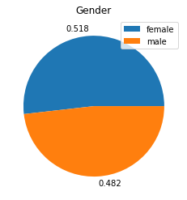

```python
aux1 = df['gender'].value_counts()
plt.pie(aux1, labels = aux1/sum(aux1))
plt.title('Gender')
plt.legend(aux1.index)
```

> **Gender**: Our dataset students are separated in 51.8% females and 48.2% males. Considering that our dataset is composed by 1,000 students, that means 518 female students and 482 male students. We have a higher quantity of females, but still they are in similar numbers. Gender should not have impact in students performance, but we could look at the distribution of performance by gender later on.

#### What is the distribution of the students by lunch specifications?

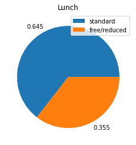

```python
aux2 = df['lunch'].value_counts()
plt.pie(aux2, labels = aux2/sum(aux2))
plt.title('Lunch')
plt.legend(aux2.index)
```

> **Lunch**: Most of the students have regular lunch (645 of them), but there is a considerable amount of students (355 of them) who have free or reduced lunch. Later on I would like to investigate if that interferes in the students performance.

#### What is the distribution of the students by test preparation course status?

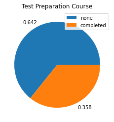

```python
aux3 = df['test preparation course'].value_counts()
plt.pie(aux3, labels = aux3/sum(aux3))
plt.title('Test Preparation Course')
plt.legend(aux3.index)
```

> **Test Preparation Course** Most of our students has not completed the test preparation course. Only 358 of them have done that. We can check if those students have a better score than the others.

#### What is the distribution of the students by race/ethnicity group?

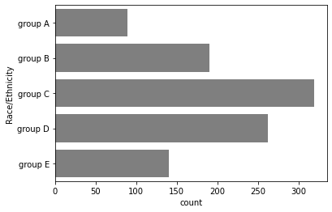

```python
order1 = ['group A', 'group B','group C','group D','group E']
sb.countplot(data=df, y='race/ethnicity', color = sb.color_palette()[7], order = order1)
plt.ylabel('Race/Ethnicity')
```

> **Race/Ethnicity**: The biggest group of students is Group C, followed by Group D and Group B. Race or ethnicity should not be a factor of impact in students performance, but we can check if the groups presented have different social/economic situations by looking at the relation between this variable and others such as lunch and parental level of education.

#### What is the distribution of the students by parental level of education?

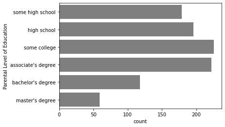

```python
order2 = ['some high school', 'high school', 'some college', "associate's degree", "bachelor's degree", "master's degree"]
sb.countplot(data=df, y='parental level of education', color = sb.color_palette()[7],  order = order2)
plt.ylabel('Parental Level of Education')
```

> **Parental Level of Education**: The students parents most often have some college, an associate's degree or at least have completed or attended to high school. Most of them, otherwise, did not get to have a bachelor or master's degree. We should see if that interferes in their kids performance.

Now, let's take a look at the quantitative variables (which are also our interest variables). I used histograms to do that.

#### How do math, writing and reading scores vary among students?

I created a set related charts: three histrograms, one to each subject. This way we can look at the distributions and also compare the three of them by seeing them side by side.

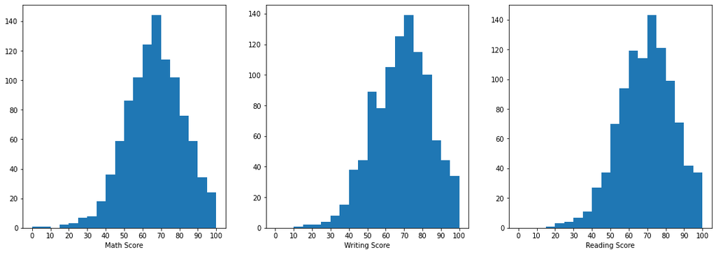

```python
plt.figure(figsize = [18, 6])

plt.subplot(1, 3, 1)
plt.hist(data = df, x = 'math score', bins = np.arange(0, df['math score'].max()+5, 5));
ticks =  np.arange(0, df['math score'].max()+10, 10);
labels = ['{}'.format(i) for i in ticks];
plt.xlabel('Math Score');
plt.xticks(ticks, labels);

plt.subplot(1, 3, 2)
plt.hist(data = df, x = 'writing score', bins = np.arange(0, df['writing score'].max()+5, 5));
ticks =  np.arange(0, df['writing score'].max()+10, 10);
labels = ['{}'.format(i) for i in ticks];
plt.xlabel('Writing Score');
plt.xticks(ticks, labels);

plt.subplot(1, 3, 3)
plt.hist(data = df, x = 'reading score', bins = np.arange(0, df['reading score'].max()+5, 5));
ticks =  np.arange(0, df['reading score'].max()+10, 10);
labels = ['{}'.format(i) for i in ticks];
plt.xlabel('Reading Score');
plt.xticks(ticks, labels);
```

> **Math Score**: We can see that the math score distribution is skewed, with most students getting scores around 65-70. A few students got grades between 0 and 10. Later on we can try to understand which factors are characteristics of the students who got lower grades.

> **Writing Score**: The writing score distribution has two peaks: most students got grades between 70 and 75 (higher than the math score), but the second peak is located aroud 50-55.

> **Reading Score**: The reading score distribution is similar to the writing distribution, with the higher peak around 70-75. It appears that the students with good writing skills also have good reading skills.

Now, I would like to create a new variable in the dataset: the mean score. I'd like to look at its distribution two. This variable will now become our main variable of interest, since we will calculate it from the math, writing and reading scores.

```python
mean_score = []

#I will iterate through the dataframe creating the array with the mean score
for row in df.iterrows():
    mean_score.append((row[1]['math score'] + row[1]['writing score'] + row[1]['reading score'])/3)

#I will add the mean score array to the dataframe
df['mean score'] = mean_score

df.head()
```

|  | gender | race/ethnicity | parental level of education | lunch | test preparation course | math score | reading score | writing score | mean score |
| --- | --- | --- | --- | --- | --- | --- | --- | --- | --- |
| 0 | female | group B | bachelor's degree | standard | none | 72 | 72 | 74 | 72.666667 |
| 1 | female | group C | some college | standard | completed | 69 | 90 | 88 | 82.333333 |
| 2 | female | group B | master's degree | standard | none | 90 | 95 | 93 | 92.666667 |
| 3 | male | group A | associate's degree | free/reduced | none | 47 | 57 | 44 | 49.333333 |
| 4 | male | group C | some college | standard | none | 76 | 78 | 75 | 76.333333 |

#### How does the mean score vary among students?

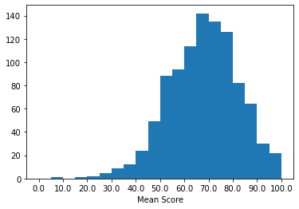

```python
plt.hist(data = df, x = 'mean score', bins = np.arange(0, df['mean score'].max()+5, 5));
ticks =  np.arange(0, df['mean score'].max()+10, 10);
labels = ['{}'.format(i) for i in ticks];
plt.xlabel('Mean Score');
plt.xticks(ticks, labels);
```

> **Mean Score**: The mean score has a skewed distribution, as expected, and most students have a mean score around 65-70. We should see which factors interfere in this score later.

### Discuss the distribution(s) of your variable(s) of interest. Were there any unusual points? Did you need to perform any transformations?

> The dataset appears to be clean and the only transformation needed was the creation of the mean score. The univariate exploration was able to provide a lot of insights and questions to be answered later. All this information are presented above.

### Of the features you investigated, were there any unusual distributions? Did you perform any operations on the data to tidy, adjust, or change the form of the data? If so, why did you do this?

> I did not have to perform any data wrangling steps, only some feature engineering (creation of the mean score column).

## Bivariate Exploration

I won't explore the relation between all variables in the dataset. Instead, I will analyse the relations that seem to have impact in the mean score or in the score of each subject. I already cited a few points that we could explore in the previous exploration. Now I will look deeper into them.

#### How does Math, Writing, Reading and Mean scores vary by gender?

I created a set of violin charts so that we could see the distribution of each score by gender and also compare the subjects (math, writing and reading) and mean score to each other.

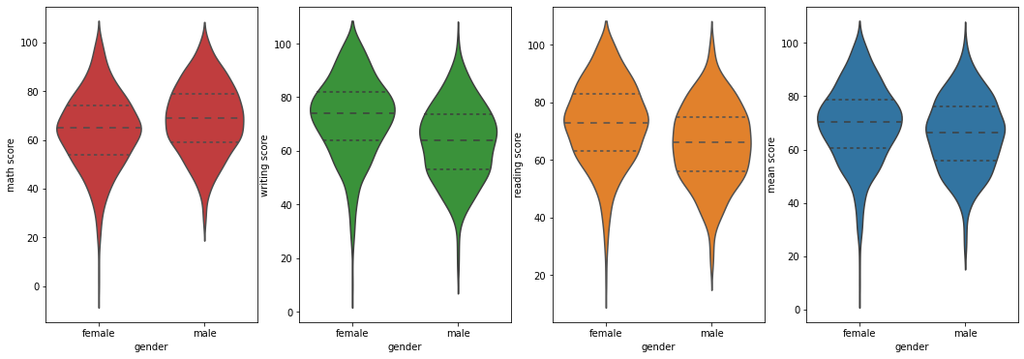

```python
plt.figure(figsize = [18, 6])

plt.subplot(1, 4, 1)
sb.violinplot(data=df, x='gender', y='math score', color=sb.color_palette()[3], inner='quartile');

plt.subplot(1, 4, 2)
sb.violinplot(data=df, x='gender', y='writing score', color=sb.color_palette()[2], inner='quartile');

plt.subplot(1, 4, 3)
sb.violinplot(data=df, x='gender', y='reading score', color=sb.color_palette()[1], inner='quartile');

plt.subplot(1, 4, 4)
sb.violinplot(data=df, x='gender', y='mean score', color=sb.color_palette()[0], inner='quartile');
```

> For this analysis, I will consider that the number of students in each gender does not vary enough to bias the visualizations. I colored each subplot with different colors to separate the variables analyzed. This are some insights we can get from the visualizations above:
> - Female students have a higher median of mean scores.
> - Female students have higher grades in writing and reading scores, but male students have better scores in math. This can also be cause by the hypothesis that students with good reading skills also have good writing skills.

#### How does the mean score vary by lunch specifications? Are they impacted by them?

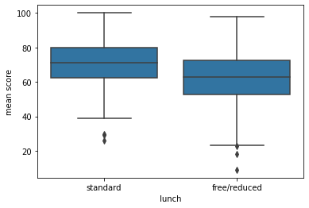

```python
sb.boxplot(data=df, x='lunch', y='mean score', color=sb.color_palette()[0]);
```

> **Mean score vs. lunch**: We can clearly see that students that have a free (probably of lower quality than a paid for) or reduced lunch have lower mean scores. That probably happens because those students who eat better also feel physically better and have more physical and mental health in the moments they are studying.

#### Do students who completed the test preparation course have higher scores?

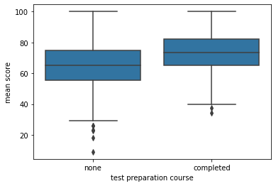

```python
sb.boxplot(data=df, x='test preparation course', y='mean score', color=sb.color_palette()[0]);
```

> **Mean score vs. test preparation course**: Students that have completed the test preparation course have a better performance than others. The course can be considered then effective.

#### How does the mean score vary by parental level of education?

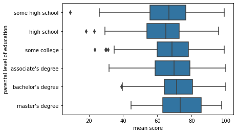

```python
sb.boxplot(data=df, y='parental level of education', x='mean score', color=sb.color_palette()[0], order = ['some high school', 'high school', 'some college', "associate's degree", "bachelor's degree", "master's degree"]);
```

> **Parental level of education**: Except for the students with parents that only attended to high school, the higher the parental level of education, the higher the students performance, measured by the mean score. The students with parents eith higher lever of education probably have a better financial condiction, home structure and/or inspiration to pursue higher education. In case of students whose parents did not complete high school, we could suppose that a considerable quantity of them could want to have a different reality for themselves.

#### Do lunch specifications vary among the groups of Race/Ethnicity?

I created a set of charts to see lunch specifications to each ethnicity group and compare them to each other.

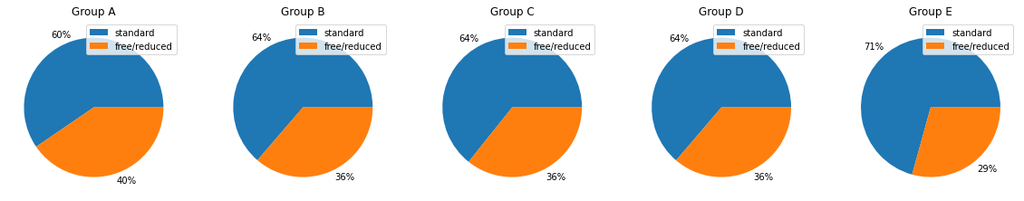

```python
plt.figure(figsize = [20, 6])

plt.subplot(1, 5, 1)
aux = df['lunch'][df['race/ethnicity'] == 'group A'].value_counts()
plt.pie(aux, labels = ["{:.0%}".format(i) for i in aux/sum(aux)])
plt.title('Group A')
plt.legend(aux.index)

plt.subplot(1, 5, 2)
aux = df['lunch'][df['race/ethnicity'] == 'group B'].value_counts()
plt.pie(aux, labels = ["{:.0%}".format(i) for i in aux/sum(aux)])
plt.title('Group B')
plt.legend(aux.index)

plt.subplot(1, 5, 3)
aux = df['lunch'][df['race/ethnicity'] == 'group C'].value_counts()
plt.pie(aux, labels = ["{:.0%}".format(i) for i in aux/sum(aux)])
plt.title('Group C')
plt.legend(aux.index)

plt.subplot(1, 5, 4)
aux = df['lunch'][df['race/ethnicity'] == 'group D'].value_counts()
plt.pie(aux, labels = ["{:.0%}".format(i) for i in aux/sum(aux)])
plt.title('Group D')
plt.legend(aux.index)

plt.subplot(1, 5, 5)
aux = df['lunch'][df['race/ethnicity'] == 'group E'].value_counts()
plt.pie(aux, labels = ["{:.0%}".format(i) for i in aux/sum(aux)])
plt.title('Group E')
plt.legend(aux.index)
```

> **Race/Ethnicity vs. Lunch**: Looking at the pie chart we can see that the Group A has a higher percentage of students that eat free or reduced lunch, which could indicate that this group is somehow disavantaged by society. We could say the opposite about group E. The other groups seem to share the same place in society.

#### Do some groups of race/ethnicity actually have lower/higher score than others?

I created a set of charts to see mean score to each ethnicity group and compare them to each other.

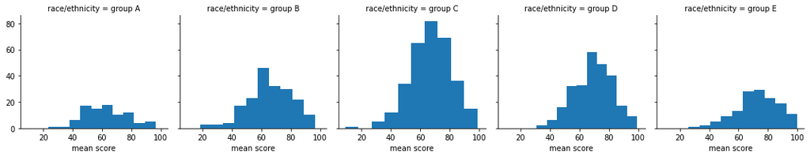

```python
g = sb.FacetGrid(data = df, col = 'race/ethnicity', col_order = ['group A', 'group B','group C','group D','group E']);
g.map(plt.hist, "mean score");
```

```python
df[['race/ethnicity','mean score']].groupby('race/ethnicity').mean()
```

| race/ethnicity | mean score |
| --- | --- |
| group A | 62.992509 |
| group B | 65.468421 |
| group C | 67.131661 |
| group D | 69.179389 |
| group E | 72.752381 |

> **Race/Ethnicity vs. Mean Score 2**: Using the groupby function we can see that group A really has the lowest performance in mean score an that group E has the best, enforcing our hypothesis of disavantaged and privileged groups. We can also see that group D has better performance than group C, which has better performance than group B.

## Multivariate Exploration

#### Which gender is more impacted by the luch differences between students?

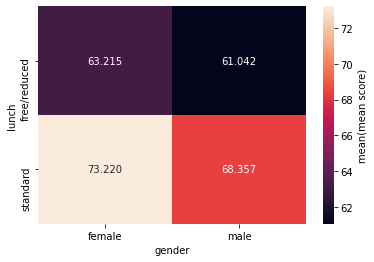

```python
means = df.groupby(['lunch', 'gender']).mean()['mean score']
means = means.reset_index(name = 'mean score')
means = means.pivot(index = 'lunch', columns = 'gender', values = 'mean score')
sb.heatmap(means, annot = True, fmt = '.3f', cbar_kws = {'label' : 'mean(mean score)'})
```

> With this chart we can see that females with standart lunch have a 10 points higher score than with free/reduced lunch, while to male students the difference is only 7.3 higher. The color variation from free/reduced to standart lunch is stronger to females than to males.

#### What is the relation between the math, writing and reading scores?

I have an hypothesis that students with good writing skills have also goos reading skills, so I will put these two scores in the x and y axes. I divided the dataframe in two groups: the first 500 students and the last 500 students for better visualization of the data.

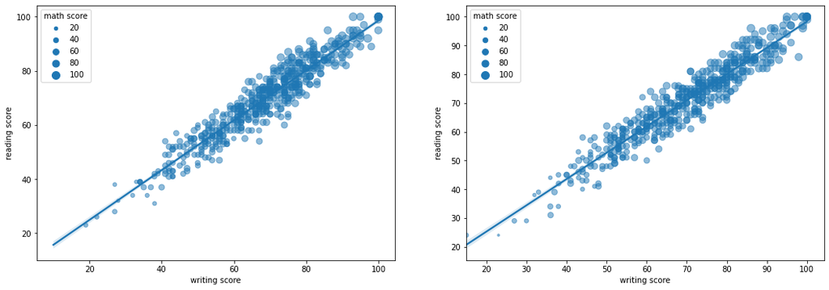

```python
plt.figure(figsize = [18, 6])

sizes = [20, 40, 60, 80, 100]
base_color = sb.color_palette()[0]
legend_obj = []
for i in sizes:
    legend_obj.append(plt.scatter([], [], s = i, color = base_color))

plt.subplot(1, 2, 1)
sb.regplot(data = df.head(500), x = 'writing score', y = 'reading score', x_jitter = 0.05, scatter_kws = {'s' : df['math score'].head(500), 'alpha': 0.5})
plt.legend(legend_obj, sizes, title="math score")
plt.subplot(1, 2, 2)
sb.regplot(data = df.tail(500), x = 'writing score', y = 'reading score', x_jitter = 0.05, scatter_kws = {'s' : df['math score'].tail(500), 'alpha': 0.5})
plt.legend(legend_obj, sizes, title="math score")
```

> There are two conclusions that we can get from these plots:
> - Relation between reading and writing scores appear to be linear, positive and strong;
> - Students with the lowest scores in reading and writing appear to have also low grade in math, and the same happens to students with the highest grades. But in the middle of the grade interval this pattern does not seem to be always mantained.

#### Does the pattern above vary by gender?

I will plot two charts similar to the above, the first with female students and the second with male students.

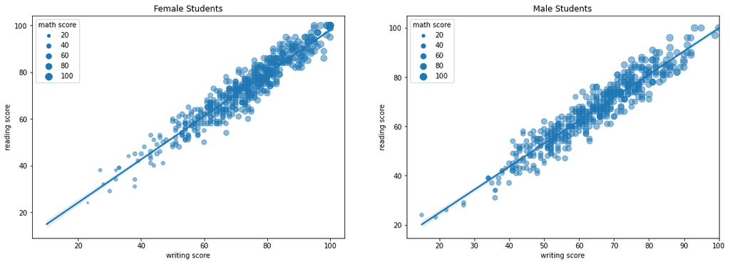

```python
plt.figure(figsize = [18, 6])

sizes = [20, 40, 60, 80, 100]
base_color = sb.color_palette()[0]
legend_obj = []
for i in sizes:
    legend_obj.append(plt.scatter([], [], s = i, color = base_color))

plt.subplot(1, 2, 1)
sb.regplot(data = df[df['gender'] == 'female'], x = 'writing score', y = 'reading score', x_jitter = 0.05, scatter_kws = {'s' : df[df['gender'] == 'female']['math score'], 'alpha': 0.5})
plt.legend(legend_obj, sizes, title="math score")
plt.title('Female Students')
plt.subplot(1, 2, 2)
sb.regplot(data = df[df['gender'] == 'male'], x = 'writing score', y = 'reading score', x_jitter = 0.05, scatter_kws = {'s' : df[df['gender'] == 'male']['math score'], 'alpha': 0.5})
plt.legend(legend_obj, sizes, title="math score")
plt.title('Male Students')
```

> - We can see that female students have have a higher quantity of grades concentraded in higher intervales of writing and reading scores. Their math grade seems to increse with the writing and reading grades, but their math grades seem to be lower than to male students.
> - Male students do not have a performance as goos as females in terms of writing and reading scores, but their math scores appear to be much better than the female math scores. Also, the relation between math score and the other two scores in the case of male students, although is evident, do not appear to be as strong as to female students.